# Project 1 Multiple Regression

Jefferson Ong, Jayne Hollar, Céline Prunet

3/15/2020

```r
library(readxl)
library(tidyverse)
house <- read_excel("Housing.xlsx")
```

# Data Summary:

Examine the statistics and values for each variable. Are any missing? Do any values need clarification or modification? If so, why and what did you do?

```r
str(house)
```

```
Classes 'tbl_df', 'tbl' and 'data.frame':   76 obs. of  11 variables:
 $ id             : num  1 2 3 4 5 6 7 8 9 10 ...
 $ price          : num  388 450 386 350 156 ...
 $ size           : num  2.18 2.05 2.11 1.44 1.8 ...
 $ lot            : num  4 5 5 6 1 5 4 4 4 5 ...
 $ bath           : num  3 3 2 1 2 2 1.1 2 2.1 2.1 ...
 $ bedrooms       : num  4 4 4 2 4 3 4 4 4 3 ...
 $ yearbuilt      : num  1940 1957 1955 1956 1994 ...
 $ agestandardized: num  -3 -1.3 -1.5 -1.4 2.4 -3 -1.2 -0.9 -0.5 -0.2 ...
 $ garagesize     : num  0 2 2 1 1 1 1 2 2 2 ...
 $ status         : chr  "sld" "sld" "sld" "act" ...
 $ elem           : chr  "edison" "edison" "edison" "adams" ...
```

```r
summary(house)
```

```
       id            price            size            lot
 Min.   : 1.00   Min.   :155.5   Min.   :1.440   Min.   : 1.000
 1st Qu.:19.75   1st Qu.:242.8   1st Qu.:1.861   1st Qu.: 3.000
 Median :38.50   Median :276.0   Median :1.966   Median : 4.000
 Mean   :38.50   Mean   :285.8   Mean   :1.970   Mean   : 3.987
 3rd Qu.:57.25   3rd Qu.:336.8   3rd Qu.:2.107   3rd Qu.: 5.000
 Max.   :76.00   Max.   :450.0   Max.   :2.896   Max.   :11.000
      bath          bedrooms       yearbuilt    agestandardized
 Min.   :1.000   Min.   :2.000   Min.   :1905   Min.   :-6.50000
 1st Qu.:2.000   1st Qu.:3.000   1st Qu.:1958   1st Qu.:-1.22500
 Median :2.000   Median :3.000   Median :1970   Median :-0.05000
 Mean   :2.208   Mean   :3.447   Mean   :1969   Mean   :-0.05921
 3rd Qu.:3.000   3rd Qu.:4.000   3rd Qu.:1980   3rd Qu.: 1.00000
 Max.   :3.100   Max.   :6.000   Max.   :2005   Max.   : 3.50000
   garagesize       status              elem
 Min.   :0.000   Length:76          Length:76
 1st Qu.:1.000   Class :character   Class :character
 Median :2.000   Mode  :character   Mode  :character
 Mean   :1.566
 3rd Qu.:2.000
 Max.   :3.000
```

- Here is a quick look at the dataset

```r
which(is.na(house))
```

```
integer(0)
```

- None are missing in the data frame

## Do any values need clarification or modification?

- Yes status should be a factor rather than just characters.

```r
unique(house$status)
```

```
[1] "sld" "act" "pen"
```

```r
unique(house$elem)
```

```
[1] "edison" "adams"  "parker" "edge"   "harris" "crest"
```

- We needed to see all the different elements in these variables.

```r
house$status <- as.factor(c("sld" = "1", "pen" = "2", "act" = "3")[house$status])
house$status
```

```
 [1] 1 1 1 3 1 1 3 1 3 1 3 1 1 2 1 3 3 3 3 3 2 1 1 1 1 1 3 1 2 2 3 3 2 3 1 1 1 1
[39] 3 2 3 1 1 1 2 1 2 1 1 1 2 1 1 1 1 1 3 3 3 2 3 1 1 2 2 2 3 3 3 1 3 1 1 1 3 3
Levels: 1 2 3
```

```r
house$elem <- as.factor(c("edison" = "1", "adams" = "2", "parker" = "3", "edge" = "4", "harris" = 5, "crest" = 6)[house$elem])
house$elem
```

```
 [1] 1 1 1 2 2 2 3 3 3 3 4 4 4 4 5 4 4 4 4 1 3 3 3 4 4 5 3 1 4 1 6 6 5 5 1 4 1 4
[39] 3 3 6 3 4 1 4 4 4 4 4 6 4 1 4 1 4 4 5 5 5 5 5 5 5 1 4 5 4 5 6 3 3 5 3 4 3 6
Levels: 1 2 3 4 5 6
```

- Here we changed status of the house into a factor of three levels where sld = 1, meaning 1 when the house is sold, pen = 2 where the house is pending sale, and act = 3 where house is in the active listing. We did the same for the elementary school distrinct

# Exploratory Data Analysis:

## Scatterplot

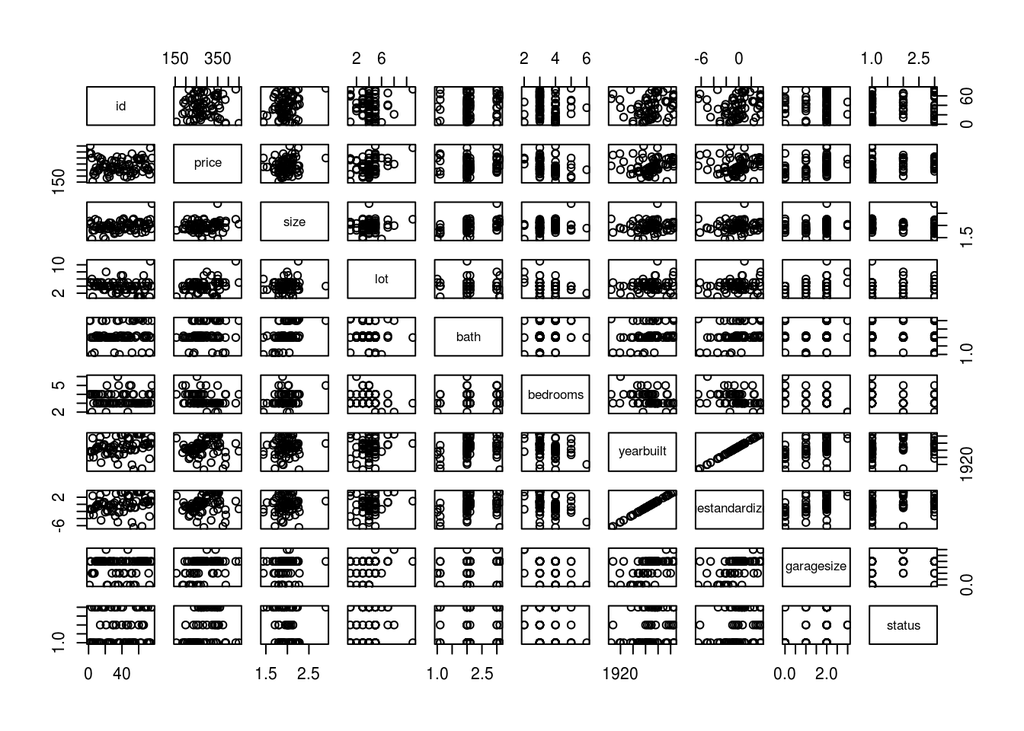

```r
plot(house[1:10])
```

- If we look at the second row of this multi-scatterplot, we can see the relationship of price as y against all the other variables individually. We can see that bath, bedroom, garagesize, and status are discrete variables. We can consider them as factors where a house’s bathroom will either have 1, 2, or 3 bathrooms but for now we won’t, in an extreme case of a house having more than 3 bathroom. Where as a house can only have three states.

## Correlation plot

The variables: size, lot, bedrooms, yearbuilt/agestandardized has outliers

```r
cor(house[, c(1:9)])
```

```
                         id       price       size         lot       bath
id               1.00000000  0.04662108 0.27241069 -0.10244192  0.1547756
price            0.04662108  1.00000000 0.20143783  0.24423228  0.1746578
size             0.27241069  0.20143783 1.00000000  0.04079199  0.4725406
lot             -0.10244192  0.24423228 0.04079199  1.00000000 -0.1709961
bath             0.15477558  0.17465777 0.47254061 -0.17099609  1.0000000
bedrooms        -0.04912302 -0.28619746 0.23845303 -0.21382977  0.1468258
yearbuilt        0.22294217  0.15412476 0.17656934 -0.03933975  0.3345239
agestandardized  0.22294217  0.15412476 0.17656934 -0.03933975  0.3345239
garagesize       0.03559640  0.35838608 0.17315776  0.23581664  0.2017635
                   bedrooms   yearbuilt agestandardized garagesize
id              -0.04912302  0.22294217      0.22294217  0.0355964
price           -0.28619746  0.15412476      0.15412476  0.3583861
size             0.23845303  0.17656934      0.17656934  0.1731578
lot             -0.21382977 -0.03933975     -0.03933975  0.2358166
bath             0.14682576  0.33452385      0.33452385  0.2017635
bedrooms         1.00000000 -0.36315062     -0.36315062 -0.4038039
yearbuilt       -0.36315062  1.00000000      1.00000000  0.5371846
agestandardized -0.36315062  1.00000000      1.00000000  0.5371846
garagesize      -0.40380395  0.53718464      0.53718464  1.0000000
```

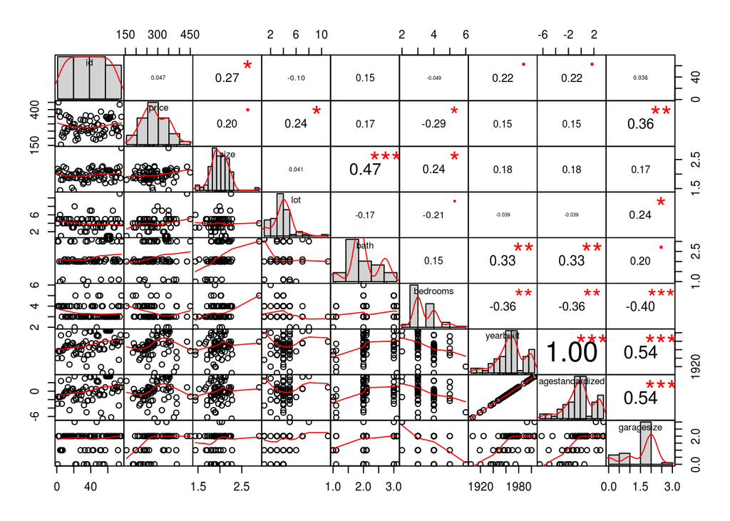

```r
library("PerformanceAnalytics")
chart.Correlation(house[, c(1:9)], histogram=TRUE, pch=19)
```

- Here we can see that price as a single predictor against the other variables. We can see that individually each predictor doesn’t correlate strongly to price.

Examine some of the variables relationships with price to help you determine which variables might be useful in an initial model. Explain your conclusions from this initial screening.

- We can see that the promising predictor variables are garagesize, lot, bedrooms(negatively). We can look further in size, bath, yearbuilt/agestandardized if we need more predictors. It makes sense that id doesn’t predict anythign since its just an index and that yearbuilt and agestandardized are the same since agestandardized is just a transformation of yearbuilt.
- We wanted to see why bedroom is negatively correlated since it’s not intuitive that having more bedrooms mean that the house is a lower price. We can see from the scatterplot that houses that have 4 or more bedrooms typically cost less than the 2 or 3 bedroom counterparts.

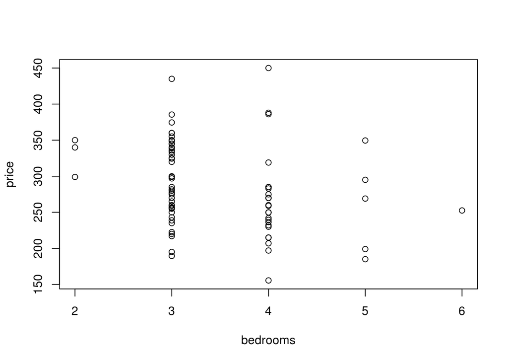

```r
sample <- house %>%
  select(bedrooms, price) %>%
  arrange(bedrooms)
plot(sample)
```

## Outliers

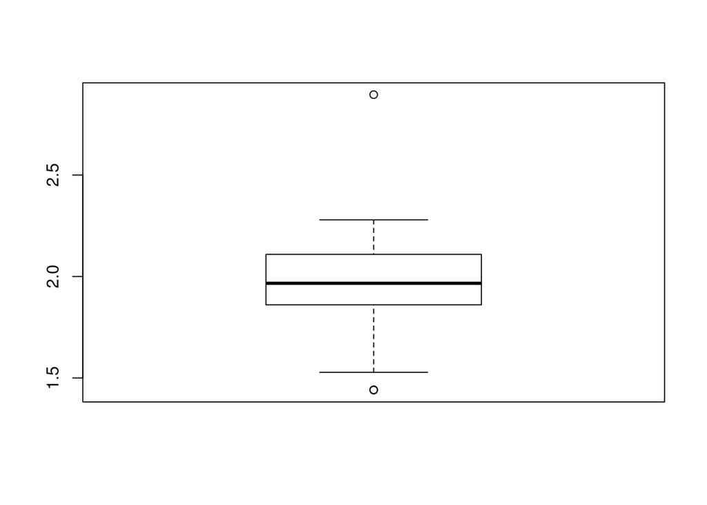

```r
OutVals = boxplot(house$size, plot = T)$out
```

```r
which(house$size %in% OutVals)
```

```
[1]  4 20 76
```

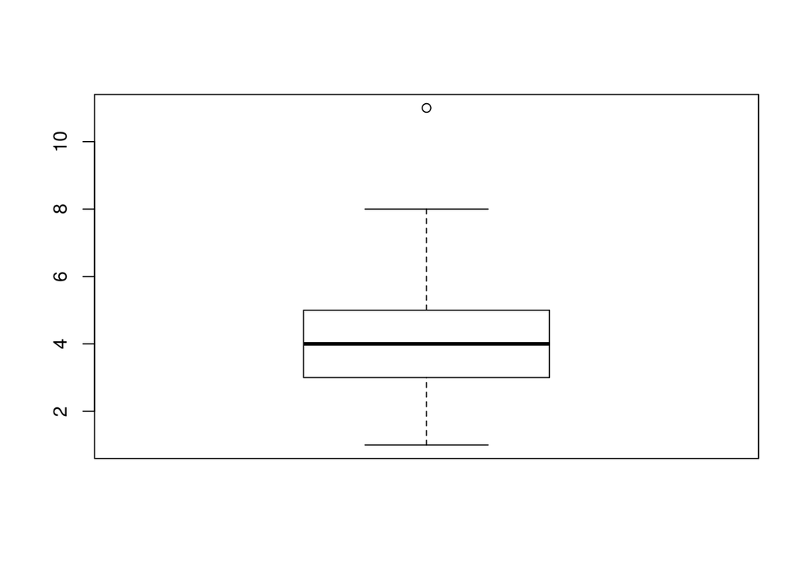

```r
OutVals = boxplot(house$lot, plot = T)$out
```

```r
which(house$lot %in% OutVals)
```

```
[1] 74
```

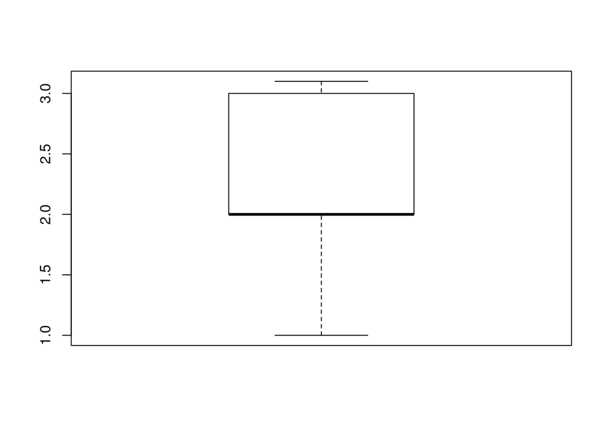

```r
OutVals = boxplot(house$bath, plot = T)$out
```

```r
which(house$bath %in% OutVals)
```

```
integer(0)
```

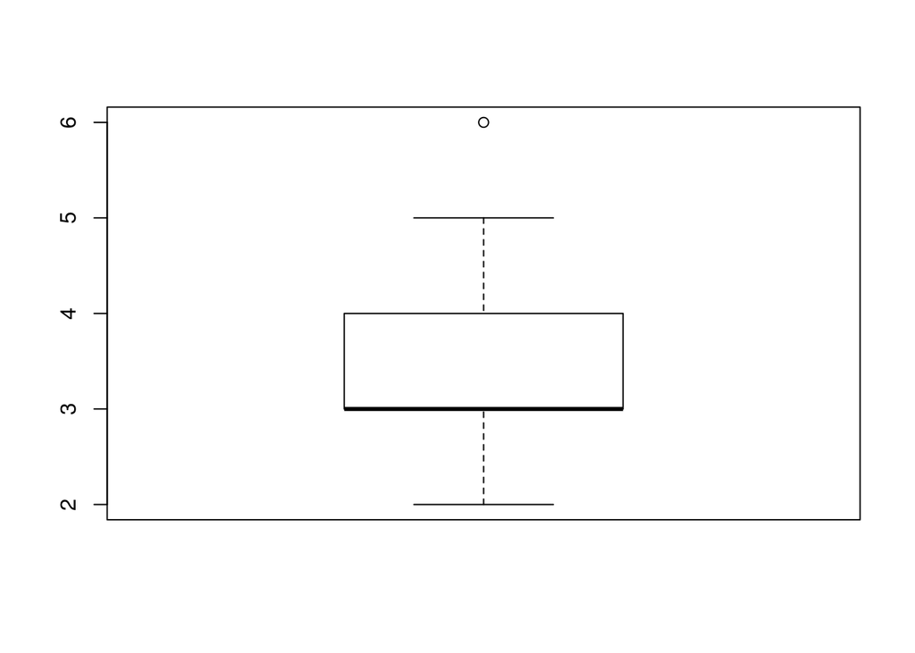

```r
OutVals = boxplot(house$bedrooms, plot = T)$out
```

```r
which(house$bedrooms %in% OutVals)
```

```
[1] 35
```

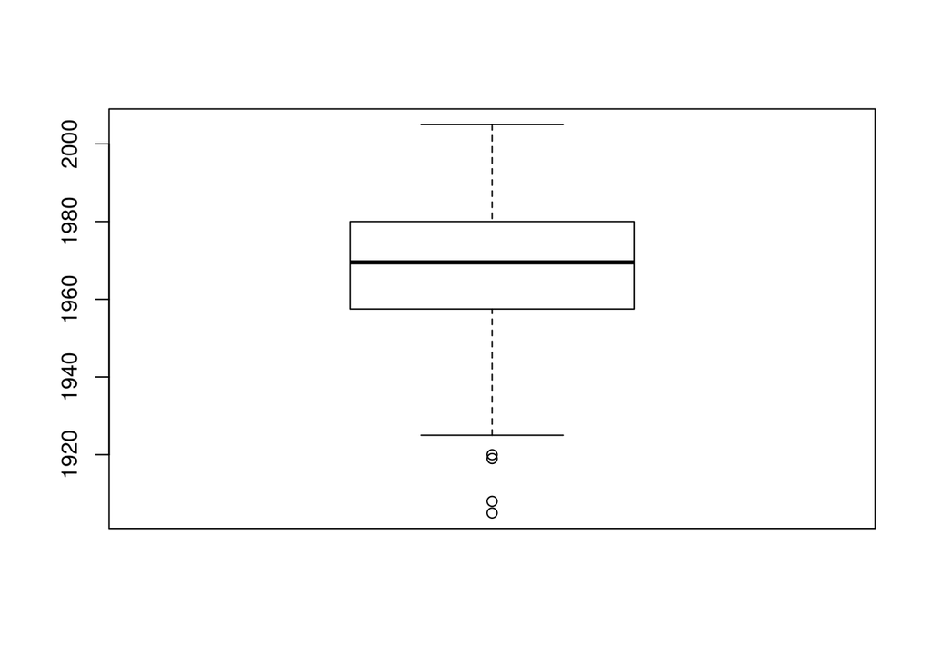

```r
OutVals = boxplot(house$yearbuilt, plot = T)$out
```

```r
which(house$yearbuilt %in% OutVals)
```

```
[1] 35 52 54 64
```

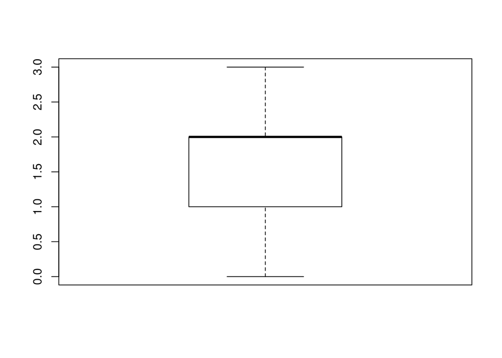

```r
OutVals = boxplot(house$garagesize, plot = T)$out
```

```r
which(house$garagesize %in% OutVals)
```

```
integer(0)
```

- We went ahead and look at size, lot, bath, bedroom, yearbuilt, and garagesize for outliers since id is just an index, price because it’s what we’re tryin to predict, and agestandardized as it will give the same as yearbuilt. Boxplot would not be appropriate in for status and elem since it wouldn’t make sense.

```r
house$size[c(4, 20, 76)]
```

```
[1] 1.442 1.440 2.896
```

```r
house$lot[c(74)]
```

```
[1] 11
```

```r
#house$bath
house$bedrooms[c(35)]
```

```
[1] 6
```

```r
house$yearbuilt[c(35, 52, 54, 64)]
```

```
[1] 1920 1919 1905 1908
```

```r
#house$garagesize
```

- We then looked at the individual points to see if the data can explain why these particular points are outliers. We found that houses built before the 1920 has the 6 bedroom home which explains some of the negative correlation between price and bedroom numbers. An intuition would be that older homes, especially those before the 1920s will cost more and have more bedrooms.

```r
house[c(74, 76),]
```

```
# A tibble: 2 x 11
     id price  size   lot  bath bedrooms yearbuilt agestandardized garagesize
  <dbl> <dbl> <dbl> <dbl> <dbl>    <dbl>     <dbl>           <dbl>      <dbl>
1    74  435   2.25    11     2        3      1979             0.9          2
2    76  350.  2.90     4     3        5      1979             0.9          2
# … with 2 more variables: status <fct>, elem <fct>
```

- We then looked at the row 74 and 76 since 74 had a particuarly large lot and 76 had a huge size. We found that theres nothing apparent that would explain this deviation and decided to remove them because of this. They aren’t representative of the data at hand. We will also remove id as it isn’t needed for our analysis

```r
house <- house[-c(74,76), ]
house <- subset(house, select = -id )
str(house)
```

```
Classes 'tbl_df', 'tbl' and 'data.frame':   74 obs. of  10 variables:
 $ price          : num  388 450 386 350 156 ...
 $ size           : num  2.18 2.05 2.11 1.44 1.8 ...
 $ lot            : num  4 5 5 6 1 5 4 4 4 5 ...
 $ bath           : num  3 3 2 1 2 2 1.1 2 2.1 2.1 ...
 $ bedrooms       : num  4 4 4 2 4 3 4 4 4 3 ...
 $ yearbuilt      : num  1940 1957 1955 1956 1994 ...
 $ agestandardized: num  -3 -1.3 -1.5 -1.4 2.4 -3 -1.2 -0.9 -0.5 -0.2 ...
 $ garagesize     : num  0 2 2 1 1 1 1 2 2 2 ...
 $ status         : Factor w/ 3 levels "1","2","3": 1 1 1 3 1 1 3 1 3 1 ...
 $ elem           : Factor w/ 6 levels "1","2","3","4",..: 1 1 1 2 2 2 3 3 3 3 ...
```

# Initial Modeling:

```r
model1 <- lm(price ~. -agestandardized , house)
summary(model1)
```

```
Call:
lm(formula = price ~ . - agestandardized, data = house)

Residuals:
    Min      1Q  Median      3Q     Max
-90.440 -28.267  -3.084  25.464 105.416

Coefficients:
             Estimate Std. Error t value Pr(>|t|)
(Intercept) 180.12650  645.20317   0.279  0.78107
size         53.86491   35.98329   1.497  0.13965
lot           5.48249    4.24177   1.293  0.20114
bath          9.28329   11.71581   0.792  0.43127
bedrooms    -13.29101    9.06656  -1.466  0.14789
yearbuilt     0.01577    0.32888   0.048  0.96191
garagesize   10.42915    9.34539   1.116  0.26889
status2      23.92906   15.67594   1.526  0.13214
status3      37.64023   13.91346   2.705  0.00887 **
elem2       -83.25149   30.26369  -2.751  0.00785 **
elem3       -92.11682   20.04856  -4.595 2.28e-05 ***
elem4       -82.59376   17.25125  -4.788 1.14e-05 ***
elem5       -37.13928   21.15790  -1.755  0.08431 .
elem6       -78.42943   26.30829  -2.981  0.00414 **
---
Signif. codes:  0 '***' 0.001 '**' 0.01 '*' 0.05 '.' 0.1 ' ' 1

Residual standard error: 43.92 on 60 degrees of freedom
Multiple R-squared:  0.5297,    Adjusted R-squared:  0.4278
F-statistic: 5.199 on 13 and 60 DF,  p-value: 4.292e-06
```

Using your conclusions from the exploratory data analysis, build a regression model and report your findings.

- We can see that the model isn’t just random and does explain the price in someway, by the p-value on the F-statistic.

# Model Modification:

Consider modifying your model based upon your initial results and/or diagnostic plots from the model. Explain any modifications that you are making. Consider variance inflation factors for each predictor in your model and comment on that in your model selection process.

```r
library(car)
vif(model1)
```

```
               GVIF Df GVIF^(1/(2*Df))
size       1.629861  1        1.276660
lot        1.447221  1        1.203005
bath       1.688067  1        1.299256
bedrooms   1.626480  1        1.275335
yearbuilt  2.310691  1        1.520096
garagesize 2.005255  1        1.416070
status     1.687671  2        1.139782
elem       2.841724  5        1.110090
```

- Using the GVIF^(1/(2*Df)) since elem has 5 coefficients and status has df 2, for all the different factors. There isn’t much multicollinearity between the predictor variables.

```r
model2 <- lm(price ~. -agestandardized -yearbuilt -bath -lot -garagesize, house)
summary(model2)
```

```
Call:
lm(formula = price ~ . - agestandardized - yearbuilt - bath -
    lot - garagesize, data = house)

Residuals:
    Min      1Q  Median      3Q     Max
-88.973 -25.321  -2.025  25.832 130.000

Coefficients:
            Estimate Std. Error t value Pr(>|t|)
(Intercept)  237.969     66.128   3.599 0.000624 ***
size          78.424     31.368   2.500 0.014987 *
bedrooms     -19.763      7.791  -2.537 0.013640 *
status2       32.561     14.984   2.173 0.033481 *
status3       45.721     13.154   3.476 0.000920 ***
elem2        -88.205     29.473  -2.993 0.003925 **
elem3        -90.014     18.000  -5.001 4.72e-06 ***
elem4        -78.548     15.838  -4.959 5.50e-06 ***
elem5        -39.243     18.458  -2.126 0.037360 *
elem6        -77.364     25.034  -3.090 0.002958 **
---
Signif. codes:  0 '***' 0.001 '**' 0.01 '*' 0.05 '.' 0.1 ' ' 1

Residual standard error: 44.24 on 64 degrees of freedom
Multiple R-squared:  0.4909,    Adjusted R-squared:  0.4193
F-statistic: 6.856 on 9 and 64 DF,  p-value: 7.769e-07
```

```r
vif(model2)
```

```
             GVIF Df GVIF^(1/(2*Df))
size     1.220356  1        1.104697
bedrooms 1.183316  1        1.087803
status   1.390658  2        1.085938
elem     1.452477  5        1.038032
```

- We then started to remove predictor variables base on the highest p value on their individual t statistic. While also keeping in mind the vif at each iteration on whether one would show multicollinearity, this is not occur. After removing yearbuilt and bath we saw size became significant. When we removed lot bedroom started to show that it might be significant and finally removing garagesize, we end up with a model where all the predictors are significant.
- The p value on the f-statistic shows us this is a significant model overall with a R^2 of 49%, adjusted of 41%.

```r
par(mfrow = c(2,2))
plot(model2)
```

[output not shown]

```r
house[4,]
```

```
# A tibble: 1 x 10
  price  size   lot  bath bedrooms yearbuilt agestandardized garagesize status
  <dbl> <dbl> <dbl> <dbl>    <dbl>     <dbl>           <dbl>      <dbl> <fct>
1   350  1.44     6     1        2      1956            -1.4          1 3
# … with 1 more variable: elem <fct>
```

```r
model3 <- lm(price ~. -agestandardized -yearbuilt -bath -lot -garagesize + agestandardized:size, house)
summary(model3)
```

```
Call:
lm(formula = price ~ . - agestandardized - yearbuilt - bath -
    lot - garagesize + agestandardized:size, data = house)

Residuals:
    Min      1Q  Median      3Q     Max
-91.001 -25.479  -1.336  25.801 126.792

Coefficients:
                     Estimate Std. Error t value Pr(>|t|)
(Intercept)           243.908     66.997   3.641 0.000551 ***
size                   74.545     32.027   2.328 0.023160 *
bedrooms              -17.784      8.359  -2.127 0.037302 *
status2                30.712     15.298   2.008 0.048975 *
status3                43.926     13.478   3.259 0.001804 **
elem2                 -91.547     30.014  -3.050 0.003344 **
elem3                 -94.588     19.316  -4.897 7.11e-06 ***
elem4                 -83.323     17.420  -4.783 1.08e-05 ***
elem5                 -45.933     21.039  -2.183 0.032753 *
elem6                 -80.453     25.558  -3.148 0.002513 **
size:agestandardized    1.003      1.492   0.672 0.503828
---
Signif. codes:  0 '***' 0.001 '**' 0.01 '*' 0.05 '.' 0.1 ' ' 1

Residual standard error: 44.43 on 63 degrees of freedom
Multiple R-squared:  0.4945,    Adjusted R-squared:  0.4143
F-statistic: 6.163 on 10 and 63 DF,  p-value: 1.756e-06
```

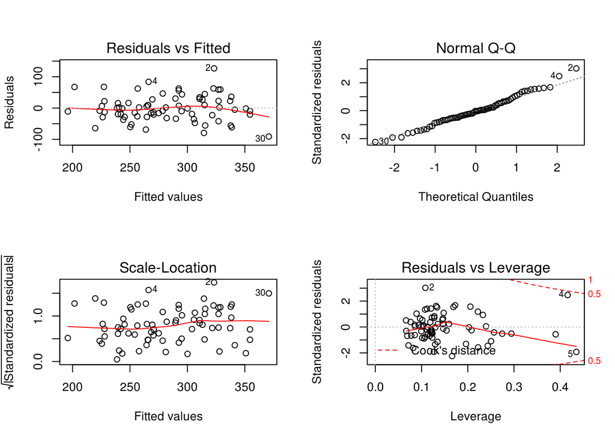

```r
par(mfrow = c(2,2))
plot(model3)
```

- Here we’ve looked at the interaction term that we thought we be significant earlier from looking at the data. We find out that is it not.

```r
model4 <- lm(log(price) ~. -agestandardized -yearbuilt -bath -lot -garagesize, house)
summary(model4)
```

```
Call:
lm(formula = log(price) ~ . - agestandardized - yearbuilt - bath -
    lot - garagesize, data = house)

Residuals:
     Min       1Q   Median       3Q      Max
-0.28833 -0.08378 -0.00452  0.08781  0.36940

Coefficients:
            Estimate Std. Error t value Pr(>|t|)
(Intercept)  5.49603    0.23240  23.649  < 2e-16 ***
size         0.26461    0.11024   2.400 0.019297 *
bedrooms    -0.07492    0.02738  -2.736 0.008028 **
status2      0.11963    0.05266   2.272 0.026468 *
status3      0.17636    0.04623   3.815 0.000309 ***
elem2       -0.35659    0.10358  -3.443 0.001020 **
elem3       -0.30834    0.06326  -4.874 7.54e-06 ***
elem4       -0.26894    0.05566  -4.832 8.82e-06 ***
elem5       -0.12941    0.06487  -1.995 0.050308 .
elem6       -0.26248    0.08798  -2.983 0.004031 **
---
Signif. codes:  0 '***' 0.001 '**' 0.01 '*' 0.05 '.' 0.1 ' ' 1

Residual standard error: 0.1555 on 64 degrees of freedom
Multiple R-squared:  0.5106,    Adjusted R-squared:  0.4417
F-statistic: 7.418 on 9 and 64 DF,  p-value: 2.502e-07
```

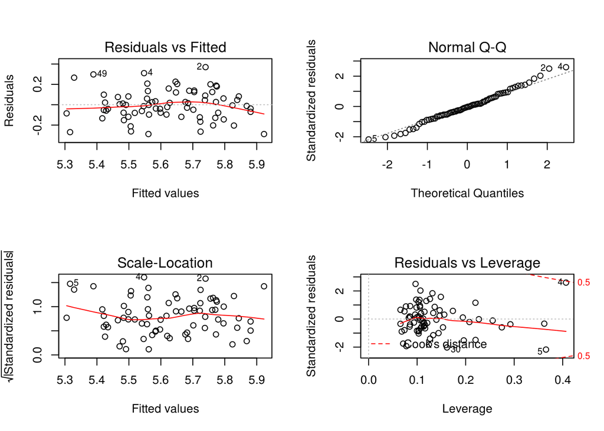

```r
par(mfrow = c(2,2))
plot(model4)
```

- We applied a transformation on the Y response variable, seeing if it will yield to better plot diagnostics. It doesn’t change much for the most part aside from the residual vs fitted plot being more spread out but curving more drastically.

```r
model4 <- lm(price ~ elem + status + I(size /100) + bedrooms, house)
summary(model4)
```

```
Call:
lm(formula = price ~ elem + status + I(size/100) + bedrooms,
    data = house)

Residuals:
    Min      1Q  Median      3Q     Max
-88.973 -25.321  -2.025  25.832 130.000

Coefficients:
            Estimate Std. Error t value Pr(>|t|)
(Intercept)  237.969     66.128   3.599 0.000624 ***
elem2        -88.205     29.473  -2.993 0.003925 **
elem3        -90.014     18.000  -5.001 4.72e-06 ***
elem4        -78.548     15.838  -4.959 5.50e-06 ***
elem5        -39.243     18.458  -2.126 0.037360 *
elem6        -77.364     25.034  -3.090 0.002958 **
status2       32.561     14.984   2.173 0.033481 *
status3       45.721     13.154   3.476 0.000920 ***
I(size/100) 7842.351   3136.758   2.500 0.014987 *
bedrooms     -19.763      7.791  -2.537 0.013640 *
---
Signif. codes:  0 '***' 0.001 '**' 0.01 '*' 0.05 '.' 0.1 ' ' 1

Residual standard error: 44.24 on 64 degrees of freedom
Multiple R-squared:  0.4909,    Adjusted R-squared:  0.4193
F-statistic: 6.856 on 9 and 64 DF,  p-value: 7.769e-07
```

```r
par(mfrow = c(2,2))
plot(model4)
```

[output not shown]

- We applied a transformation on size to see changes in the plot diagnostics. We can see that changes in the predictor variables does not have any affects on it’s significances.

# Conclusions:

Present your final model and diagnostic plots in support of that final model. In that presentation of the final model, comment on the R-squared value and its interpretation, give 95% confidence intervals for each of the β coefficients in your model, and illustrate your model’s use with a 95% confidence interval for the mean response and a 95% prediction interval for individual response for a hypothetical house of your choosing.

```r
modelf <- lm(price ~ elem + status + size + bedrooms, house)
summary(modelf)
```

```
Call:
lm(formula = price ~ elem + status + size + bedrooms, data = house)

Residuals:
    Min      1Q  Median      3Q     Max
-88.973 -25.321  -2.025  25.832 130.000

Coefficients:
            Estimate Std. Error t value Pr(>|t|)
(Intercept)  237.969     66.128   3.599 0.000624 ***
elem2        -88.205     29.473  -2.993 0.003925 **
elem3        -90.014     18.000  -5.001 4.72e-06 ***
elem4        -78.548     15.838  -4.959 5.50e-06 ***
elem5        -39.243     18.458  -2.126 0.037360 *
elem6        -77.364     25.034  -3.090 0.002958 **
status2       32.561     14.984   2.173 0.033481 *
status3       45.721     13.154   3.476 0.000920 ***
size          78.424     31.368   2.500 0.014987 *
bedrooms     -19.763      7.791  -2.537 0.013640 *
---
Signif. codes:  0 '***' 0.001 '**' 0.01 '*' 0.05 '.' 0.1 ' ' 1

Residual standard error: 44.24 on 64 degrees of freedom
Multiple R-squared:  0.4909,    Adjusted R-squared:  0.4193
F-statistic: 6.856 on 9 and 64 DF,  p-value: 7.769e-07
```

```r
par(mfrow = c(2,2))
plot(modelf)
```

[output not shown]

- After looking at the transformation on the on the response, interaction terms, and some of the predictor variables. We did not find anything compelling that would improve the model from what we already had.
- The R^2 value is 0.4909 which mean that the model explains about 49% of the variation. Looking at the adjusted R^2 of 0.4193 we’re penalized by the amount of variables in the model.

```r
confint(modelf)
```

```
                  2.5 %     97.5 %
(Intercept)  105.864025 370.074216
elem2       -147.083452 -29.326497
elem3       -125.974296 -54.054080
elem4       -110.188716 -46.906813
elem5        -76.117722  -2.368995
elem6       -127.375332 -27.352433
status2        2.627647  62.494973
status3       19.442006  71.999903
size          15.759564 141.087464
bedrooms     -35.326602  -4.198871
```

- This is the β coefficients in your model, we are 95% confidence that the actual point is between these numbers.
- We can be 95% confident that the actual value for elem2 is between -147.083452 to -29.326497.
- We can be 95% confident that the actual value for elem3 is between -125.974296 to -54.054080.
- We can be 95% confident that the actual value for elem4 is between -110.188716 to -46.906813.
- We can be 95% confident that the actual value for elem5 is between -76.117722 to -2.368995.
- We can be 95% confident that the actual value for elem6 is between -127.375332 to -27.352433.
- We can be 95% confident that the actual value for status2 is between 2.627647 to 62.494973.
- We can be 95% confident that the actual value for status3 is between 19.442006 to 71.999903.
- We can be 95% confident that the actual value for size is between 15.759564 to 141.087464.
- We can be 95% confident that the actual value for bedrooms is between -35.326602 to -4.198871.

```r
newhouse <- data.frame(size = 2, bedrooms  = 4, status = "1", elem = "3")
predict(modelf, newdata = newhouse, interval = 'confidence')
```

```
      fit      lwr      upr
1 225.751 199.6205 251.8815
```

```r
newhouse <- data.frame(size = 2, bedrooms  = 4, status = "1", elem = "3")
predict(modelf, newdata = newhouse, interval = 'predict')
```

```
      fit      lwr      upr
1 225.751 133.5833 317.9188
```